# Vector-borne disease models in R

SPARK short course, Indonesia, March 2023

Presenter: [Trish Campbell](https://www.doherty.edu.au/people/patricia-trish-campbell), The University of Melbourne at The Peter Doherty Institute for Infection and Immunity

## Contributors

- Developed by the presenter, [Trish Campbell](https://www.doherty.edu.au/people/patricia-trish-campbell), The University of Melbourne at The Peter Doherty Institute for Infection and Immunity

# Summary

In this practical, we will code the vector-borne disease model developed in the previous session, adapt it to include more realism, explore how the behaviour of the system changes as some of our assumptions change and discuss how interventions might be included in the model.

**Part 1** covers:

- Coding a model for dengue transmission
- Running the model and plotting the results
- Comparing the modelled output to published case numbers

**Part 2** covers:

- Adapting the model to include exposed compartments
- Comparing the modelled output to published case numbers

**Part 3** covers:

- Adapting the model to include seasonality
- Comparing the modelled output to published case numbers

**Part 4** covers:

- Identifying different interventions that could be used for dengue control
- Identifying of the various model elements on which an intervention acts
- Discuss in groups how the model would need to be adapted

### Setting up your system

Before we begin developing a model, we need to set up our system.

As in previous sessions, we will start by creating a new file and writing a short description of your code to summarise its purpose for future users. Below is an example of such a description for this session. Open your course RStudio Project and download the Session 8 starter script. Save it with your course files and open it in RStudio. The script already contains the header below.

```r
#############################################################
## MODELLING VECTOR-BORNE DISEASES PRACTICAL SESSION PART 1##
#############################################################

# A model for dengue transmission - Part 1
# Some R code to numerically solve a set of ordinary differential equations
# for a simple model of dengue. Results are then plotted.
```

### Save your new file

Save your script regularly as you work through the practical session.

### Set working directory

Remember to set your working directory. As in previous sessions, you can set the working directory by tabbing: Session/Set Working Directory/To Source Location

The better way is to re-use the RStudio Project you’ve been using so far (if you have one of them), and your working directory will be set automatically.

### Load required packages

Install the required packages once with `install.packages(c("dplyr", "deSolve", "ggplot2"))`. The starter script then loads them with `library()`.

```r
# Library imports
library(dplyr)
library(deSolve)
library(ggplot2)
```

## **Part 1:** A model for dengue

### Problem description

In the previous session, we developed a model for a mosquito-borne disease. Here, we will code that model in R and parameterise it using typical values applicable to dengue transmission.

### Define the model parameters and time period for simulations

As we saw in previous sessions, model parameters must be estimated either from literature or from a model. In developing this model for dengue, we will use parameter values obtained from the following paper:

Ndii, M.Z., Hickson, R.I., Allingham, D. and Mercer, G.N., 2015. Modelling the transmission dynamics of dengue in the presence of *Wolbachia*. *Mathematical Biosciences*, 262, pp.157–166.

| Parameter | Name | Value | Units |
| --- | --- | --- | --- |
| Number of bites | bites | 0.63 | per mosquito per day |
| Probability of transmission - mosquito to human | T_HM | 0.26 | NA |
| Probability of transmission - human to mosquito | T_MH | 0.26 | NA |
| Duration of infection - humans | infectious period | 5 | days |
| Mosquito birth and death rate | mu_M | 1/14 | per day |

Using the table of parameter names and values above, copy and paste the following code chunk into your editor and complete the code by entering the VALUE, NAME and DESCRIPTION where they are missing:

```r
# Model parameters
parameters <- c(
 bites = VALUE, # number of bites per mosquito per day
 NAME = 0.26, # probability of transmission - mosquito to human
 T_MH = 0.26, # DESCRIPTION
 infectious_period = 5, # days
 mu_M = VALUE # DESCRIPTION
)
```

We also need to specify the start time and end time for our simulation, as well as the time step to report values. We will use the times specified in the Ndii et al. paper. Copy and paste the code chunk below into your editor, and complete by specifying the arguments to the `seq`function, indicated as VALUE, VALUE, VALUE using a time step of 1 day:

```r
# Time window
start_date = as.Date("2008-11-02")
end_date = as.Date("2009-05-31")
times = seq(VALUE, VALUE, VALUE)
```

### Set up the initial conditions

The Ndii et al. paper develops a model for dengue transmission in the city of Cairns, Australia, which had an approximate human population of 150,000 in 2008. The carrying capacity for the mosquito population (the maximum population that can be supported without environmental degradation) is related to the number of available breeding sites, which in turn is dependent on the number of humans. The Ndii et al paper sets the carrying capacity at three times the human population, and so we will assume an initial mosquito population size of 450,000, half of which is female. We only model female mosquitoes as they are the only ones that transmit infection. Our simulations will commence with 2 infectious humans and 10 infectious mosquitoes, with all remaining humans and mosquitoes susceptible.

Using this information, copy and paste the following code chunk into your editor and complete the code by entering VALUE where it is missing, and calculating the population in the human recovered compartment and mosquito infectious compartment using the values of other variables (where EXPRESSION USING OTHER VARIABLES is indicated):

```r
# Initial conditions
human_population <- VALUE # population of Cairns in 2008
initial_human_susceptible <- VALUE
initial_human_infectious <- 2
initial_human_recovered <- EXPRESSION USING OTHER VARIABLES
mosquito_population <- 225000
initial_mosquito_susceptible <- VALUE
initial_mosquito_infectious <- EXPRESSION USING OTHER VARIABLES
```

### Define the model variables (also known as compartments or states)

We define the compartments of our model, initialise the value of each using the initial conditions and then gather them together in a single variable. Copy and paste the code chunk below into your editor and complete the code by entering VALUE where it is missing:

```r
# Define model compartments, gather into a single variable to capture the state
# of the system and set to initial values
state <- c(Susceptible_human = VALUE,
           Infectious_human = VALUE,
           Recovered_human = VALUE,
           Susceptible_mosquito = VALUE,
           Infectious_mosquito = VALUE)
```

### Set up a function to solve the equations

Now that we have defined our parameters, compartments and initial conditions, we will write a function to numerically solve our dengue model using the model equations developed in the previous session. Copy and paste the incomplete code chunk below into your editor and complete the code by replacing the text indicated by EXPRESSION USING OTHER VARIABLES:

```r
# Model function
dengue_base <- function(t, state, parameters){
  with(as.list(c(state, parameters)), {
    # Calculate the total population sizes
    Total_human_population <- EXPRESSION USING OTHER VARIABLES
    Total_mosquito_population <- EXPRESSION USING OTHER VARIABLES

    # Calculate the average force of infection imposed on each susceptible human
    force_of_infection_on_human <- EXPRESSION USING OTHER VARIABLES

    # Calculate the average force of infection imposed on each susceptible mosquito
    force_of_infection_on_mosquito <- EXPRESSION USING OTHER VARIABLES

    # Calculate the (net) instantaneous change in each compartment
    Susceptible_human_change <- EXPRESSION USING OTHER VARIABLES
    Infectious_human_change <- EXPRESSION USING OTHER VARIABLES
    Recovered_human_change <- EXPRESSION USING OTHER VARIABLES
    Susceptible_mosquito_change <- EXPRESSION USING OTHER VARIABLES
    Infectious_mosquito_change <- EXPRESSION USING OTHER VARIABLES

    # Return net changes as list
    return(list(
      c(
        Susceptible_human_change,
        Infectious_human_change,
        Recovered_human_change,
        Susceptible_mosquito_change,
        Infectious_mosquito_change
      )
    ))
  })
}
```

### Run the model and plot the results

We now run the model, using the code you learned in a previous session. Copy and paste the code chunk below into your editor, enter VALUE where it is missing, and then run your file:

```r
# Solve model
out_dengue_base <- ode(y = VALUE, times = as.numeric(times - times[1]),
                       func = VALUE, parms = VALUE)

# Plot solution
plot(out_dengue_base,
     main = c("Susceptible humans", "Infectious humans", "Recovered humans",
              "Susceptible mosquitoes", "Infectious mosquitoes"),
     xlab = "Time", ylab = c("population size"))
```

Your plot should look this this:

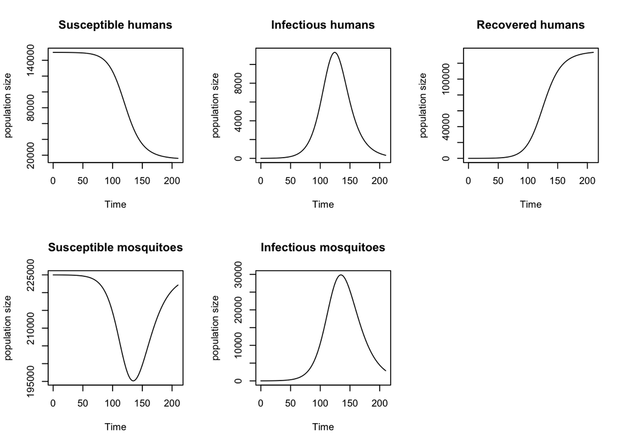

### Comparing to published dengue incidence data

- Susceptible human change = - new infections

If we can calculate susceptible human change from our model output, we will have the number of new infections. Since our model output records the number of humans in the S compartment at each of our recorded time steps, if we take the difference between these entries, we will have the susceptible human change, and we get the new infections by changing its sign. Copy and paste the code below into your editor, to convert daily prevalence into weekly incidence and plot the results:

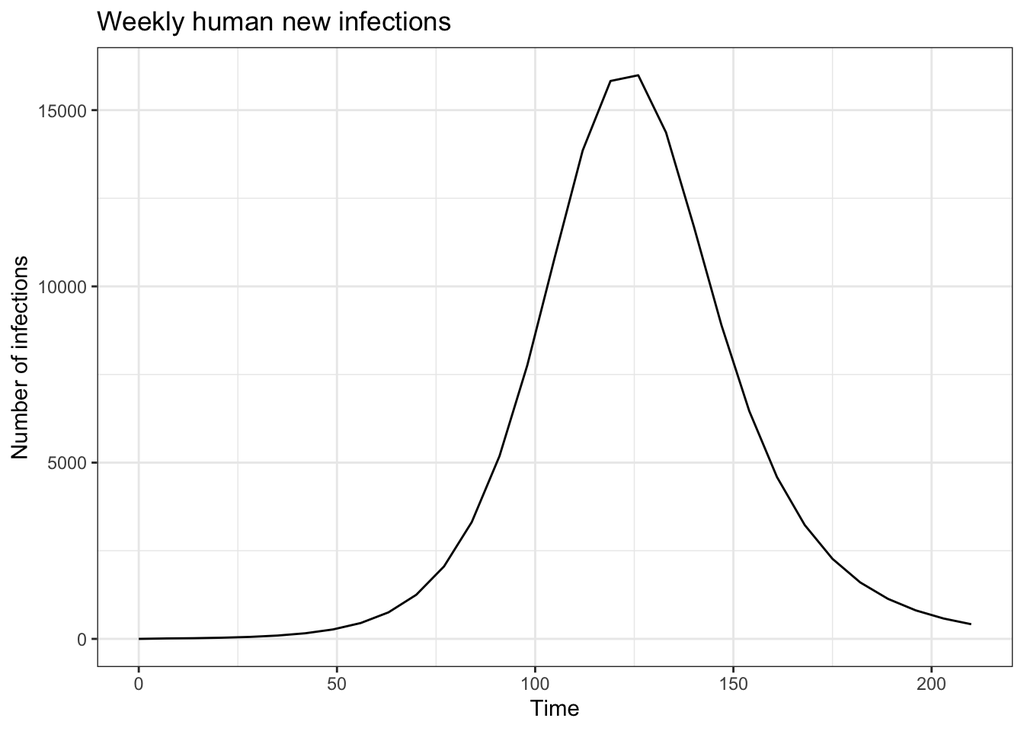

```r
# Convert ODE output to a tibble
dengue_base_infections <- tibble::as_tibble(out_dengue_base[, c("time", "Susceptible_human", "Infectious_human", "Recovered_human")])

# Create columns for new infections and cumulative new infections,
# Select every 7th row and calculate the difference
 dengue_base_infections <- dengue_base_infections  |>
                          mutate(Susceptible_human_change = -c(0, diff(Susceptible_human)),
                                 Cumulative_human_infections = cumsum(Susceptible_human_change)) |>
                          filter(time %% 7 == 0) |>
                          select(time, Cumulative_human_infections) |>
                          mutate(Weekly_human_infections = c(0, diff(Cumulative_human_infections)))


# Plot solution
ggplot(dengue_base_infections, aes(x = time, y = Weekly_human_infections)) +
  geom_line() +
  labs(
    x = "Time",
    y = "Number of infections",
    title = "Weekly human new infections"
  ) +
  theme_bw()
```

**TipNeed to catch up?**

Download the code for this session so far. This runnable script contains the completed Part 1 model.

## **Part 1:** Solutions

**Part 1: Spoiler alert**

The solutions tab contains the complete code for Part 1. **Only click on it if you have tried to complete the exercises yourself and need some help**

**Part 1: Solutions for Part 1**

By the end of Part 1, your script should look like this:

```r
#############################################################
## MODELLING VECTOR-BORNE DISEASES PRACTICAL SESSION PART 1##
#############################################################

# A model for dengue transmission - Part 1
# Some R code to numerically solve a set of ordinary differential equations
# for a simple model of dengue. Results are then plotted.

# Library imports
library(dplyr)
library(deSolve)
library(ggplot2)

# Model parameters
parameters <- c(
  bites = 0.63, # number of bites per mosquito per day
  T_HM = 0.26, # probability of transmission - mosquito to human
  T_MH = 0.26, # Probability of transmission - human to mosquito
  infectious_period = 5, # days
  mu_M = 1/14 # Mosquito birth and death rate
)

# Time window
start_date = as.Date("2008-11-02")
end_date = as.Date("2009-05-31")
times = seq(start_date, end_date, by = 1)

# Initial conditions
human_population <- 150000 # population of Cairns in 2008
initial_human_susceptible <- 149998
initial_human_infectious <- 2
initial_human_recovered <- human_population - initial_human_susceptible - initial_human_infectious
mosquito_population <- 225000
initial_mosquito_susceptible <- 224990
initial_mosquito_infectious <- mosquito_population - initial_mosquito_susceptible

# Define model compartments, gather into a single variable to capture the state of the system and set to initial values
state <- c(Susceptible_human = initial_human_susceptible,
           Infectious_human = initial_human_infectious,
           Recovered_human = initial_human_recovered,
           Susceptible_mosquito = initial_mosquito_susceptible,
           Infectious_mosquito = initial_mosquito_infectious)


# Model function
dengue_base <- function(t, state, parameters){
  with(as.list(c(state, parameters)), {
    # Calculate the total population sizes
    Total_human_population <- Susceptible_human + Infectious_human + Recovered_human
    Total_mosquito_population <- Susceptible_mosquito + Infectious_mosquito

    # Calculate the average force of infection imposed on each susceptible human
    force_of_infection_on_human <- bites * T_HM * Infectious_mosquito / Total_human_population

    # Calculate the average force of infection imposed on each susceptible mosquito
    force_of_infection_on_mosquito <- bites * T_MH * Infectious_human / Total_human_population

    # Calculate the (net) instantaneous change in each compartment
    Susceptible_human_change <- -force_of_infection_on_human * Susceptible_human
    Infectious_human_change <- force_of_infection_on_human * Susceptible_human - Infectious_human / infectious_period
    Recovered_human_change <- Infectious_human / infectious_period
    Susceptible_mosquito_change <- mu_M * Total_mosquito_population - (force_of_infection_on_mosquito + mu_M) * Susceptible_mosquito
    Infectious_mosquito_change <- force_of_infection_on_mosquito * Susceptible_mosquito - mu_M * Infectious_mosquito

    # Return net changes as list
    return(list(
      c(
        Susceptible_human_change,
        Infectious_human_change,
        Recovered_human_change,
        Susceptible_mosquito_change,
        Infectious_mosquito_change
      )
    ))
  })
}

# Solve model
out_dengue_base <- ode(y = state, times = as.numeric(times - times[1]), func = dengue_base, parms = parameters)

# Plot solution
plot(out_dengue_base,
     main = c("Susceptible humans", "Infectious humans", "Recovered humans",
              "Susceptible mosquitoes", "Infectious mosquitoes"),
     xlab = "Time", ylab = c("population size"))

# Convert ODE output to a tibble
dengue_base_infections <- tibble::as_tibble(out_dengue_base[, c("time", "Susceptible_human", "Infectious_human", "Recovered_human")])

# Create columns for new infections and cumulative new infections,
# Select every 7th row and calculate the difference
dengue_base_infections <- dengue_base_infections  |>
  mutate(Susceptible_human_change = -c(0, diff(Susceptible_human)),
         Cumulative_human_infections = cumsum(Susceptible_human_change)) |>
  filter(time %% 7 == 0) |>
  select(time, Cumulative_human_infections) |>
  mutate(Weekly_human_infections = c(0, diff(Cumulative_human_infections)))


# Plot solution
ggplot(dengue_base_infections, aes(x = time, y = Weekly_human_infections)) +
  geom_line() +
  labs(
    x = "Time",
    y = "Number of infections",
    title = "Weekly human new infections"
  ) +
  theme_bw()
```

## **Part 2:** Adapting the model

In this part, we will adapt the model we developed in Part 1 to try to better capture the Cairns dengue outbreak dynamics. It is important to note that our model in Part 1 mostly used parameter values from Ndii et al. Two of those parameters, the probability of transmission from mosquito to human (T_HM) and the probability of transmission from human to mosquito (T_MH) were **fitted** using the Ndii et al. model, which has a different structure to the model we developed in Part 1. This highlights the very important point that:

*Parameter values may not be directly transferable between models*

### What might be missing from our dengue model?

When we wrote our vector-borne disease model, we made a simplifying assumption that both humans and mosquitoes are infectious immediately upon being infected. We noted that in reality, it takes time for the infectious load to build in a host before they are capable of transmitting infection. As you have seen in previous sessions, we refer to this as the exposed period — an individual is infected, but not yet infectious. Ndii et al. account for this in their model.

**2.1 Ndii et al. use 10 days as the duration of the exposed period in mosquitoes. With mosquitoes living on average for 14 days, what do you think are the implications of this exposed period for transmission?**

**2.2 Ndii et al. use 5.5 days as the duration of the exposed period in humans. Which exposed period (mosquito or human) do you think would have a greater impact on dengue disease dynamics? Why?**

### Adding another compartment to our model diagram

Before we begin coding a new version of our model, it’s a good idea to draw the structure of the new model. Redraw the model that you produced in the previous session to include exposed compartments for both the human and the mosquito populations.

**Instructions:**

1. You can draw a diagram electronically in a program such as PowerPoint, or you can draw your diagram by hand and take a photo
2. Make sure you label all compartments as well as the inflows and outflows from each compartment.
3. Save your diagram in one of the following formats: .jpg, .gif, .png
4. Upload your diagram using the *Browse…* button below
5. If you prefer, you can describe your model in words in the space below

**NB: You can replace a file by clicking on the file name and selecting a file with a different name.**

### Adding another compartment to our model code

**2.3 To add a new compartment to our model, several aspects need to be changed. What is the additional information that needs to be provided?**

Before beginning, you should add a heading in your file indicating that you have started a new model, as the code we write here will overwrite the parameters and variables you used in Part 1, other than your final results. For example, you could copy and paste the code chunk below into your editor to start writing your code for the new model:

```r
#############################################################
## MODELLING VECTOR-BORNE DISEASES PRACTICAL SESSION PART 2##
#############################################################

# A model for dengue transmission - Part 2
# Some R code to numerically solve a set of ordinary differential equations
# for a modified model of dengue. Results are then plotted.
```

First we need to add new parameters. Copy and paste the code chunk below into your editor, enter VALUE where it is missing, and then run your file:

```r
# Model parameters
parameters <- c(
 bites = 0.63, # number of bites per mosquito per day
 T_HM = 0.26, # probability of transmission - mosquito to human
 T_MH = 0.26, # probability of transmission - human to mosquito
 infectious_period = 5, # days. Duration in infectious compartment
 mu_M = 1/14, # per day. Mosquito birth and death rate.
 exposed_period_H = VALUE, # days. Duration in exposed compartment - human
 exposed_period_M = VALUE # days. Duration in exposed compartment - mosquito
)
```

Next we need to add some new initial conditions. Let’s start with no exposed humans and no exposed mosquitoes. Copy and paste the code chunk below into your editor, completing EXPRESSION USING OTHER VARIABLES where it is missing:

```r
# Initial conditions
human_population <- 150000 # population of Cairns in 2008
initial_human_susceptible <- 149998
initial_human_exposed <- 0
initial_human_infectious <- 2
initial_human_recovered <- EXPRESSION USING OTHER VARIABLES
mosquito_population <- 225000 # 3 times human population, divided by 2
initial_mosquito_susceptible <- 224990
initial_mosquito_exposed <- 0
initial_mosquito_infectious <- EXPRESSION USING OTHER VARIABLES
```

As before, we now initialise our model states, using the initial conditions we set above. Copy and paste the code chunk below into your editor, completing EXPRESSION USING OTHER VARIABLES where it is missing:

```r
# Define model compartments, gather into a single variable to capture the
# state of the system and set to initial values
state <- c(Susceptible_human = initial_human_susceptible,
           Exposed_human = EXPRESSION USING OTHER VARIABLES,
           Infectious_human = initial_human_infectious,
           Recovered_human = initial_human_recovered,
           Susceptible_mosquito = initial_mosquito_susceptible,
           Exposed_mosquito = EXPRESSION USING OTHER VARIABLES,
           Infectious_mosquito = initial_mosquito_infectious)
```

We set up times to run the model, here extending the end date (for reasons that will become clear). Copy and paste the code chunk below into your editor, to continue your code:

```r
# Time window
start_date = as.Date("2008-11-02")
end_date = as.Date("2011-05-31")
times = seq(start_date, end_date, by = 1)
```

Next, we adapt our model function to include the changes we have made to the model structure.Copy and paste the code chunk below into your editor to continue your code:

```r
# Model function
dengue_with_E <- function(t, state, parameters){
  with(as.list(c(state, parameters)), {
    # Calculate the total population sizes
    Total_human_population <- Susceptible_human + Infectious_human +
      Recovered_human + Exposed_human
    Total_mosquito_population <- Susceptible_mosquito + Infectious_mosquito +
      Exposed_mosquito

    # Calculate the average force of infection imposed on each susceptible human
    force_of_infection_on_human <- bites * T_HM * Infectious_mosquito /
      Total_human_population

    # Calculate the average force of infection imposed on each susceptible mosquito
    force_of_infection_on_mosquito <- bites * T_MH * Infectious_human /
      Total_human_population

    # Calculate the (net) instantaneous change in each compartment
    Susceptible_human_change <- -force_of_infection_on_human * Susceptible_human
    Exposed_human_change <- force_of_infection_on_human * Susceptible_human -
      Exposed_human / exposed_period_H
    Infectious_human_change <- Exposed_human / exposed_period_H -
      Infectious_human / infectious_period
    Recovered_human_change <- Infectious_human / infectious_period
    Susceptible_mosquito_change <- mu_M * Total_mosquito_population -
      (force_of_infection_on_mosquito + mu_M) * Susceptible_mosquito
    Exposed_mosquito_change <- force_of_infection_on_mosquito *
      Susceptible_mosquito - Exposed_mosquito * (1 / exposed_period_M + mu_M)
    Infectious_mosquito_change <- Exposed_mosquito / exposed_period_M - mu_M *
      Infectious_mosquito

    # Return net changes as list
    return(list(
      c(
        Susceptible_human_change,
        Exposed_human_change,
        Infectious_human_change,
        Recovered_human_change,
        Susceptible_mosquito_change,
        Exposed_mosquito_change,
        Infectious_mosquito_change
      )
    ))
  })
}
```

**2.4 Identify the elements of the model function above that have changed compared to your model in Part 1**

We are now ready to run the model and plot the results. Note that we use a different name for the output to preserve the results from your model in Part 1. Copy and paste the code chunk below into your editor, enter VALUE where it is missing, and then run the new model parts of your file:

```r
# Solve model
out_dengue_with_E <- ode(y = VALUE, times = as.numeric(times - times[1]),
                         func = VALUE, parms = VALUE)

# Plot solution
plot(out_dengue_with_E,
     main = c("Susceptible humans", "Exposed humans", "Infectious humans",
              "Recovered humans",   "Susceptible mosquitoes",
              "Exposed mosquitoes", "Infectious mosquitoes"),
     xlab = "Time", ylab = c("population size"))
```

Your plot should look this this:

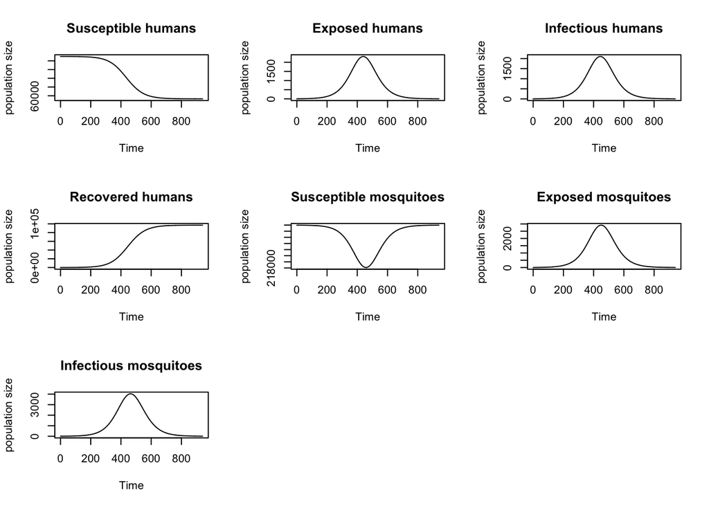

As we did in Part 1, we want to convert our dengue prevalence data to incidence data. In our new model, we have:

- Susceptible human change = - new infections
- Exposed human change = new infections - transitions to infectious
- Infectious human change = transitions to infectious - recoveries
- Recovered human change = recoveries

As before, we could calculate the difference in our susceptible population from our model output to be left with ‘new infections’ at each time step. However, the new infections in this model may not yet have come to the attention of the health system. We make the simplifying assumption that symptoms occur at the same time that a person becomes infectious, and so we count the transitions into the infectious state as our new ‘cases’ and obtain these by adding the infectious human change and recovered human change. Copy and paste the code below into your editor, to convert daily prevalence into weekly incidence and plot the results:

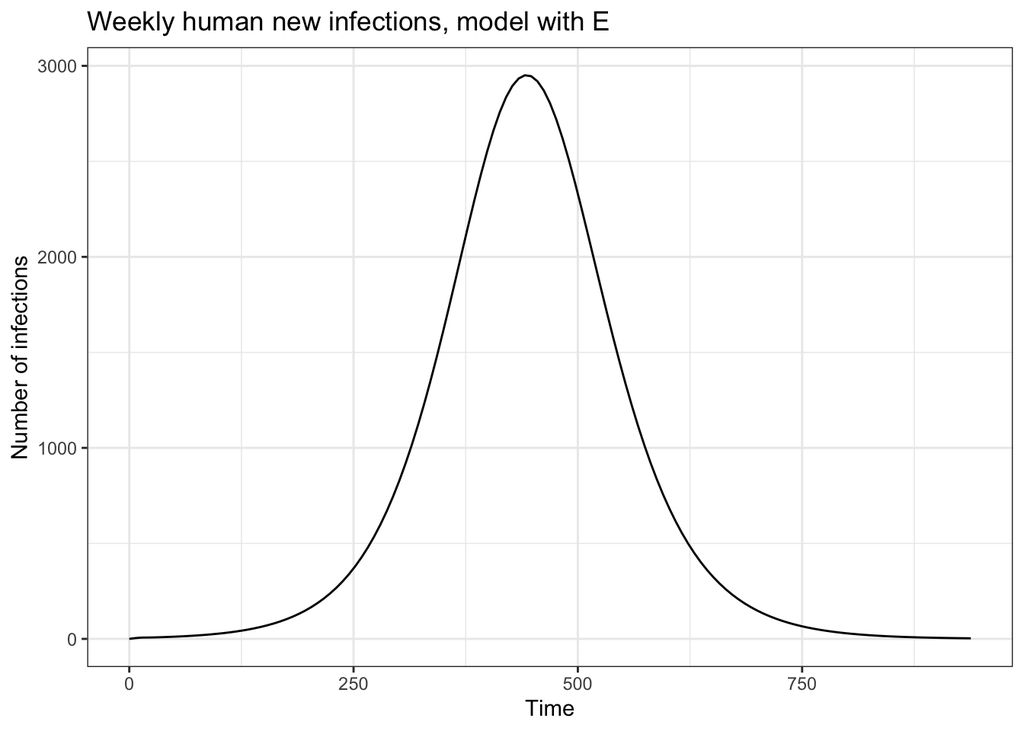

```r
# Convert ODE output to a tibble
dengue_with_E_infections <- tibble::as_tibble(
  out_dengue_with_E[, c("time", "Infectious_human", "Recovered_human")])

# Create columns for new infections and cumulative new infections,
# Select every 7th row and calculate the difference
dengue_with_E_infections <- dengue_with_E_infections  |>
                          mutate(Infectious_human_change =
                                   c(0, diff(Infectious_human)),
                                 Recovered_human_change =
                                   c(0, diff(Recovered_human)),
                                 New_human_infections =
                                   Infectious_human_change +
                                   Recovered_human_change,
                                 Cumulative_human_infections =
                                   cumsum(New_human_infections)) |>
                          filter(time %% 7 == 0) |>
                          select(time, Cumulative_human_infections) |>
                          mutate(Weekly_human_infections =
                                   c(0, diff(Cumulative_human_infections)))

# Plot solution
ggplot(dengue_with_E_infections, aes(x = time, y = Weekly_human_infections)) +
  geom_line() +
  labs(
    x = "Time",
    y = "Number of infections",
    title = "Weekly human new infections, model with E"
  ) +
  theme_bw()
```

**2.5 How do the modelled results compare to those for the model in Part 1? (Hint: Look at the magnitude and the timing of the peak.)**

**2.6 Why do you think the modelled behaviour has changed?**

**TipNeed to catch up?**

Download the code for this session so far. This runnable script contains the completed models from Parts 1 and 2.

## **Part 2:** Solutions

**Part 2: Spoiler alert**

The solutions tab contains the complete code for Parts 1 and 2. **Only click on it if you have tried to complete the exercises yourself and need some help**

**Part 2: Solutions for Part 2**

By the end of Part 2, your script should look like this:

```r
#############################################################
## MODELLING VECTOR-BORNE DISEASES PRACTICAL SESSION PART 1##
#############################################################

# A model for dengue transmission - Part 1
# Some R code to numerically solve a set of ordinary differential equations
# for a simple model of dengue. Results are then plotted.

# Library imports
library(dplyr)
library(deSolve)
library(ggplot2)

# Model parameters
parameters <- c(
  bites = 0.63, # number of bites per mosquito per day
  T_HM = 0.26, # probability of transmission - mosquito to human
  T_MH = 0.26, # Probability of transmission - human to mosquito
  infectious_period = 5, # days
  mu_M = 1/14 # Mosquito birth and death rate
)

# Time window
start_date = as.Date("2008-11-02")
end_date = as.Date("2009-05-31")
times = seq(start_date, end_date, by = 1)

# Initial conditions
human_population <- 150000 # population of Cairns in 2008
initial_human_susceptible <- 149998
initial_human_infectious <- 2
initial_human_recovered <- human_population - initial_human_susceptible - initial_human_infectious
mosquito_population <- 225000
initial_mosquito_susceptible <- 224990
initial_mosquito_infectious <- mosquito_population - initial_mosquito_susceptible

# Define model compartments, gather into a single variable to capture the state of the system and set to initial values
state <- c(Susceptible_human = initial_human_susceptible,
           Infectious_human = initial_human_infectious,
           Recovered_human = initial_human_recovered,
           Susceptible_mosquito = initial_mosquito_susceptible,
           Infectious_mosquito = initial_mosquito_infectious)


# Model function
dengue_base <- function(t, state, parameters){
  with(as.list(c(state, parameters)), {
    # Calculate the total population sizes
    Total_human_population <- Susceptible_human + Infectious_human + Recovered_human
    Total_mosquito_population <- Susceptible_mosquito + Infectious_mosquito

    # Calculate the average force of infection imposed on each susceptible human
    force_of_infection_on_human <- bites * T_HM * Infectious_mosquito / Total_human_population

    # Calculate the average force of infection imposed on each susceptible mosquito
    force_of_infection_on_mosquito <- bites * T_MH * Infectious_human / Total_human_population

    # Calculate the (net) instantaneous change in each compartment
    Susceptible_human_change <- -force_of_infection_on_human * Susceptible_human
    Infectious_human_change <- force_of_infection_on_human * Susceptible_human - Infectious_human / infectious_period
    Recovered_human_change <- Infectious_human / infectious_period
    Susceptible_mosquito_change <- mu_M * Total_mosquito_population - (force_of_infection_on_mosquito + mu_M) * Susceptible_mosquito
    Infectious_mosquito_change <- force_of_infection_on_mosquito * Susceptible_mosquito - mu_M * Infectious_mosquito

    # Return net changes as list
    return(list(
      c(
        Susceptible_human_change,
        Infectious_human_change,
        Recovered_human_change,
        Susceptible_mosquito_change,
        Infectious_mosquito_change
      )
    ))
  })
}

# Solve model
out_dengue_base <- ode(y = state, times = as.numeric(times - times[1]), func = dengue_base, parms = parameters)

# Plot solution
plot(out_dengue_base,
     main = c("Susceptible humans", "Infectious humans", "Recovered humans",
              "Susceptible mosquitoes", "Infectious mosquitoes"),
     xlab = "Time", ylab = c("population size"))

# Convert ODE output to a tibble
dengue_base_infections <- tibble::as_tibble(out_dengue_base[, c("time", "Susceptible_human", "Infectious_human", "Recovered_human")])

# Create columns for new infections and cumulative new infections,
# Select every 7th row and calculate the difference
dengue_base_infections <- dengue_base_infections  |>
  mutate(Susceptible_human_change = -c(0, diff(Susceptible_human)),
         Cumulative_human_infections = cumsum(Susceptible_human_change)) |>
  filter(time %% 7 == 0) |>
  select(time, Cumulative_human_infections) |>
  mutate(Weekly_human_infections = c(0, diff(Cumulative_human_infections)))


# Plot solution
ggplot(dengue_base_infections, aes(x = time, y = Weekly_human_infections)) +
  geom_line() +
  labs(
    x = "Time",
    y = "Number of infections",
    title = "Weekly human new infections"
  ) +
  theme_bw()

#############################################################
## MODELLING VECTOR-BORNE DISEASES PRACTICAL SESSION PART 2##
#############################################################

# A model for dengue transmission - Part 2
# Some R code to numerically solve a set of ordinary differential equations
# for a modified model of dengue. Results are then plotted.

# Model parameters
parameters <- c(
  bites = 0.63, # number of bites per mosquito per day
  T_HM = 0.26, # probability of transmission - mosquito to human
  T_MH = 0.26, # probability of transmission - human to mosquito
  infectious_period = 5, # days. Duration in infectious compartment
  mu_M = 1/14, # per day. Mosquito birth and death rate.
  exposed_period_H = 5.5, # days. Duration in exposed compartment - human
  exposed_period_M = 10 # days. Duration in exposed compartment - mosquito
)

# Initial conditions
human_population <- 150000 # population of Cairns in 2008
initial_human_susceptible <- 149998
initial_human_exposed <- 0
initial_human_infectious <- 2
initial_human_recovered <- human_population - initial_human_susceptible - initial_human_infectious - initial_human_exposed
mosquito_population <- 225000 # 3 times human population, divided by 2
initial_mosquito_susceptible <- 224990
initial_mosquito_exposed <- 0
initial_mosquito_infectious <- mosquito_population - initial_mosquito_susceptible - initial_mosquito_exposed

# Define model compartments, gather into a single variable to capture the state of the system and set to initial values
state <- c(Susceptible_human = initial_human_susceptible,
           Exposed_human = initial_human_exposed,
           Infectious_human = initial_human_infectious,
           Recovered_human = initial_human_recovered,
           Susceptible_mosquito = initial_mosquito_susceptible,
           Exposed_mosquito = initial_mosquito_exposed,
           Infectious_mosquito = initial_mosquito_infectious)

# Time window
start_date = as.Date("2008-11-02")
end_date = as.Date("2011-05-31")
times = seq(start_date, end_date, by = 1)

# Model function
dengue_with_E <- function(t, state, parameters){
  with(as.list(c(state, parameters)), {
    # Calculate the total population sizes
    Total_human_population <- Susceptible_human + Infectious_human + Recovered_human + Exposed_human
    Total_mosquito_population <- Susceptible_mosquito + Infectious_mosquito + Exposed_mosquito

    # Calculate the average force of infection imposed on each susceptible human
    force_of_infection_on_human <- bites * T_HM * Infectious_mosquito / Total_human_population

    # Calculate the average force of infection imposed on each susceptible mosquito
    force_of_infection_on_mosquito <- bites * T_MH * Infectious_human / Total_human_population

    # Calculate the (net) instantaneous change in each compartment
    Susceptible_human_change <- -force_of_infection_on_human * Susceptible_human
    Exposed_human_change <- force_of_infection_on_human * Susceptible_human - Exposed_human / exposed_period_H
    Infectious_human_change <- Exposed_human / exposed_period_H - Infectious_human / infectious_period
    Recovered_human_change <- Infectious_human / infectious_period
    Susceptible_mosquito_change <- mu_M * Total_mosquito_population - (force_of_infection_on_mosquito + mu_M) * Susceptible_mosquito
    Exposed_mosquito_change <- force_of_infection_on_mosquito * Susceptible_mosquito - Exposed_mosquito * (1 / exposed_period_M + mu_M)
    Infectious_mosquito_change <- Exposed_mosquito / exposed_period_M - mu_M * Infectious_mosquito

    # Return net changes as list
    return(list(
      c(
        Susceptible_human_change,
        Exposed_human_change,
        Infectious_human_change,
        Recovered_human_change,
        Susceptible_mosquito_change,
        Exposed_mosquito_change,
        Infectious_mosquito_change
      )
    ))
  })
}

# Solve model
out_dengue_with_E <- ode(y = state, times = as.numeric(times - times[1]), func = dengue_with_E, parms = parameters)

# Plot solution
plot(out_dengue_with_E,
     main = c("Susceptible humans", "Exposed humans", "Infectious humans", "Recovered humans",
              "Susceptible mosquitoes", "Exposed mosquitoes", "Infectious mosquitoes"),
     xlab = "Time", ylab = c("population size"))

# Convert ODE output to a tibble
dengue_with_E_infections <- tibble::as_tibble(out_dengue_with_E[, c("time", "Infectious_human", "Recovered_human")])

# Create columns for new infections and cumulative new infections,
# Select every 7th row and calculate the difference
dengue_with_E_infections <- dengue_with_E_infections  |>
  mutate(Infectious_human_change = c(0, diff(Infectious_human)),
         Recovered_human_change = c(0, diff(Recovered_human)),
         New_human_infections = Infectious_human_change + Recovered_human_change,
         Cumulative_human_infections = cumsum(New_human_infections)) |>
  filter(time %% 7 == 0) |>
  select(time, Cumulative_human_infections) |>
  mutate(Weekly_human_infections = c(0, diff(Cumulative_human_infections)))

# Plot solution
ggplot(dengue_with_E_infections, aes(x = time, y = Weekly_human_infections)) +
  geom_line() +
  labs(
    x = "Time",
    y = "Number of infections",
    title = "Weekly human new infections, model with E"
  ) +
  theme_bw()
```

## **Part 3:** The impact of seasonality

### Adding seasonality to the model

Adding an exposed compartment reduced the number of new infections, but substantially delayed the timing of the outbreak. There is still a large assumption that we have made — that the mosquito population is constant. In tropical areas, mosquito numbers fluctuate substantially over the year, with larger numbers typically seen in the wet season, which in Cairns develops in December and lasts until March. Ndii et al. incorporated such seasonality in the mosquito death rate in their model. We apply a seasonal death rate for mosquitoes using the parameters and formula applied by Ndii et al:

$$death\text{ }rate(t) = average\text{ }death\text{ }rate\left(1 - amplitude * \text{cos}\left(\frac{2\pi*\left(t + phase\right)}{365}\right)\right)$$

As before, you should add a heading in your file indicating that you have started a new model. For example, you could copy and paste the code chunk below into your editor to start writing your code for the new model:

```r
#############################################################
## MODELLING VECTOR-BORNE DISEASES PRACTICAL SESSION PART 3##
#############################################################

# A model for dengue transmission - Part 3
# Some R code to numerically solve a set of ordinary differential equations
# for a model of dengue with an exposed period and seasonality.
# Results are then plotted.
```

First we need to define the new seasonality parameters. Copy and paste the code chunk below into your editor to continue writing your code:

```r
# Add seasonality parameters
parameters <- c(
 bites = 0.63, # number of bites per mosquito per day
 T_HM = 0.26, # probability of transmission - mosquito to human
 T_MH = 0.26, # probability of transmission - human to mosquito
 infectious_period = 5, # days. Duration in infectious compartment
 mu_M = 1/14, # per day. Mosquito birth and death rate.
 exposed_period_H = 5.5, # days. Duration in exposed compartment - human
 exposed_period_M = 10, # days. Duration in exposed compartment - mosquito
 death_amplitude = 0.6228, # from Ndii et al.
 death_phase = 20.61 # days, from Ndii et al.
)
```

**3.1 What effect do you expect a seasonal death rate to have on the size of the mosquito population?**

As well as the parameters, we also need to change our initial population numbers to reflect that when our model starts in November, the mosquito population is not at its maximum value. Copy and paste the code chunk below into your editor to define the new initial conditions and initialise the compartments:

```r
# Initial conditions
human_population <- 150000 # population of Cairns in 2008
initial_human_susceptible <- 149998
initial_human_exposed <- 0
initial_human_infectious <- 2
initial_human_recovered <- human_population - initial_human_susceptible - initial_human_infectious - initial_human_exposed
mosquito_population <- 110000 # around half the maximum
initial_mosquito_susceptible <- 109990
initial_mosquito_exposed <- 0
initial_mosquito_infectious <- mosquito_population - initial_mosquito_susceptible - initial_mosquito_exposed

# Define model compartments, gather into a single variable to capture the state of the system and set to initial values
state <- c(Susceptible_human = initial_human_susceptible,
           Exposed_human = initial_human_exposed,
           Infectious_human = initial_human_infectious,
           Recovered_human = initial_human_recovered,
           Susceptible_mosquito = initial_mosquito_susceptible,
           Exposed_mosquito = initial_mosquito_exposed,
           Infectious_mosquito = initial_mosquito_infectious)
```

We set up times to run the model, returning to our original dates. Copy and paste the code chunk below into your editor, to continue your code:

```r
# Time window
start_date = as.Date("2008-11-02")
end_date = as.Date("2009-05-31")
times = seq(start_date, end_date, by = 1)
```

Next, we adapt our model function to add seasonality to the mosquito death rate.Copy and paste the code chunk below into your editor to continue your code:

```r
# Model function with seasonality
dengue_with_E_seasonal <- function(t, state, parameters){
  with(as.list(c(state, parameters)), {
    # Calculate the total population sizes
    Total_human_population <- Susceptible_human + Infectious_human + Recovered_human + Exposed_human
    Total_mosquito_population <- Susceptible_mosquito + Infectious_mosquito + Exposed_mosquito

    # Calculate the average force of infection imposed on each susceptible human
    force_of_infection_on_human <- bites * T_HM * Infectious_mosquito / Total_human_population

    # Calculate the average force of infection imposed on each susceptible mosquito
    force_of_infection_on_mosquito <- bites * T_MH * Infectious_human / Total_human_population

    # Calculate the current seasonal death rate
    mu_M_seasonal <- mu_M * (1 - death_amplitude * cos(2 * pi * (t + death_phase) / 365))

    # Calculate the (net) instantaneous change in each compartment
    Susceptible_human_change <- -force_of_infection_on_human * Susceptible_human
    Exposed_human_change <- force_of_infection_on_human * Susceptible_human - Exposed_human / exposed_period_H
    Infectious_human_change <- Exposed_human / exposed_period_H - Infectious_human / infectious_period
    Recovered_human_change <- Infectious_human / infectious_period
    Susceptible_mosquito_change <- mu_M * Total_mosquito_population - force_of_infection_on_mosquito * Susceptible_mosquito - mu_M_seasonal * Susceptible_mosquito
    Exposed_mosquito_change <- force_of_infection_on_mosquito * Susceptible_mosquito - Exposed_mosquito / exposed_period_M - mu_M_seasonal * Exposed_mosquito
    Infectious_mosquito_change <- Exposed_mosquito / exposed_period_M - mu_M_seasonal * Infectious_mosquito

    # Return net changes as list
    return(list(
      c(
        Susceptible_human_change,
        Exposed_human_change,
        Infectious_human_change,
        Recovered_human_change,
        Susceptible_mosquito_change,
        Exposed_mosquito_change,
        Infectious_mosquito_change
      )
    ))
  })
}
```

We are now ready to run the model and plot the results. Again we use a different name for the output to preserve the results from your model in Parts 1 and 2. Copy and paste the code chunk below into your editor and then run the new model parts of your file:

```r
# Solve model
out_dengue_with_E_seasonal <- ode(y = state, times = as.numeric(times - times[1]), func = dengue_with_E_seasonal, parms = parameters)

# Plot solution
plot(out_dengue_with_E_seasonal,
     main = c("Susceptible humans", "Exposed humans", "Infectious humans", "Recovered humans",
              "Susceptible mosquitoes", "Exposed mosquitoes", "Infectious mosquitoes"),
     xlab = "Time", ylab = c("population size"))
```

Your plot should look this this:

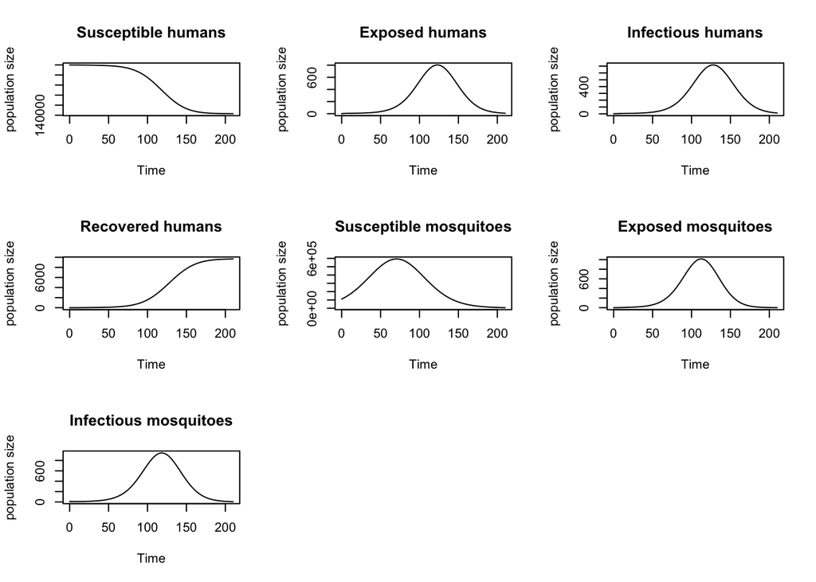

Copy and paste the code below into your editor, to convert daily prevalence into weekly incidence and plot the results:

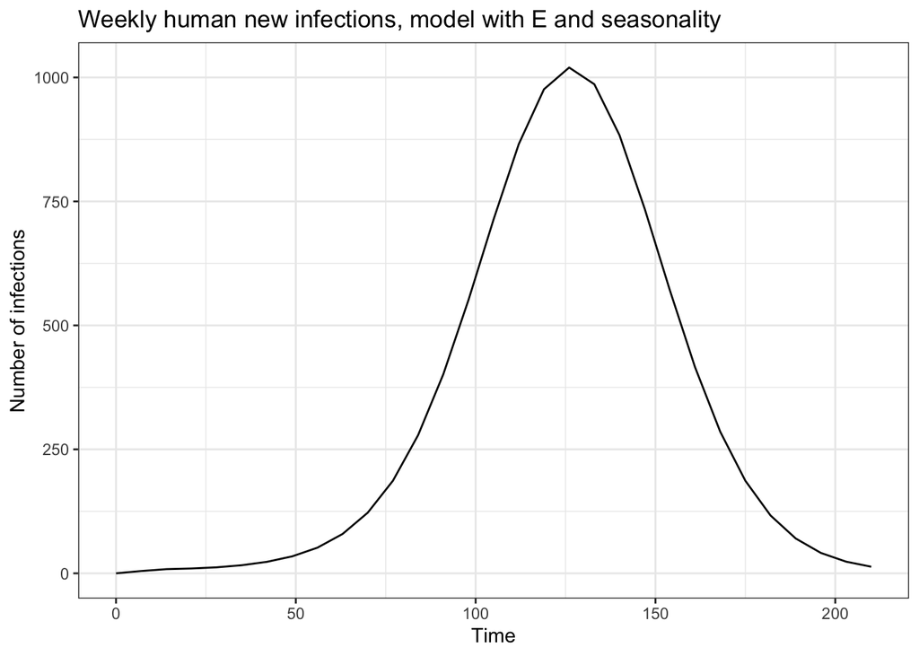

```r
# Convert ODE output to a tibble
dengue_with_E_seasonal_infections <- tibble::as_tibble(out_dengue_with_E_seasonal[, c("time", "Infectious_human", "Recovered_human")])

# Create columns for new infections and cumulative new infections,
# Select every 7th row and calculate the difference
dengue_with_E_seasonal_infections <- dengue_with_E_seasonal_infections  |>
                          mutate(Infectious_human_change = c(0, diff(Infectious_human)),
                                 Recovered_human_change = c(0, diff(Recovered_human)),
                                 New_human_infections = Infectious_human_change + Recovered_human_change,
                                 Cumulative_human_infections = cumsum(New_human_infections)) |>
                          filter(time %% 7 == 0) |>
                          select(time, Cumulative_human_infections) |>
                          mutate(Weekly_human_infections = c(0, diff(Cumulative_human_infections)))

# Plot solution
ggplot(dengue_with_E_seasonal_infections, aes(x = time, y = Weekly_human_infections)) +
  geom_line() +
  labs(
    x = "Time",
    y = "Number of infections",
    title = "Weekly human new infections, model with E and seasonality"
  ) +
  theme_bw()
```

**TipNeed to catch up?**

Download the code for this session so far. This runnable script contains the completed models from Parts 1, 2 and 3.

## **Part 3:** Solutions

**Part 3: Spoiler alert**

The solutions tab contains the complete code for Parts 1, 2 and 3. **Only click on it if you have tried to complete the exercises yourself and need some help**

**Part 3: Solutions for Part 3**

By the end of Part 3, your script should look like this:

```r
#############################################################
## MODELLING VECTOR-BORNE DISEASES PRACTICAL SESSION PART 1##
#############################################################

# A model for dengue transmission - Part 1
# Some R code to numerically solve a set of ordinary differential equations
# for a simple model of dengue. Results are then plotted.

# Library imports
library(dplyr)
library(deSolve)
library(ggplot2)

# Model parameters
parameters <- c(
  bites = 0.63, # number of bites per mosquito per day
  T_HM = 0.26, # probability of transmission - mosquito to human
  T_MH = 0.26, # Probability of transmission - human to mosquito
  infectious_period = 5, # days
  mu_M = 1/14 # Mosquito birth and death rate
)

# Time window
start_date = as.Date("2008-11-02")
end_date = as.Date("2009-05-31")
times = seq(start_date, end_date, by = 1)

# Initial conditions
human_population <- 150000 # population of Cairns in 2008
initial_human_susceptible <- 149998
initial_human_infectious <- 2
initial_human_recovered <- human_population - initial_human_susceptible - initial_human_infectious
mosquito_population <- 225000
initial_mosquito_susceptible <- 224990
initial_mosquito_infectious <- mosquito_population - initial_mosquito_susceptible

# Define model compartments, gather into a single variable to capture the state of the system and set to initial values
state <- c(Susceptible_human = initial_human_susceptible,
           Infectious_human = initial_human_infectious,
           Recovered_human = initial_human_recovered,
           Susceptible_mosquito = initial_mosquito_susceptible,
           Infectious_mosquito = initial_mosquito_infectious)


# Model function
dengue_base <- function(t, state, parameters){
  with(as.list(c(state, parameters)), {
    # Calculate the total population sizes
    Total_human_population <- Susceptible_human + Infectious_human + Recovered_human
    Total_mosquito_population <- Susceptible_mosquito + Infectious_mosquito

    # Calculate the average force of infection imposed on each susceptible human
    force_of_infection_on_human <- bites * T_HM * Infectious_mosquito / Total_human_population

    # Calculate the average force of infection imposed on each susceptible mosquito
    force_of_infection_on_mosquito <- bites * T_MH * Infectious_human / Total_human_population

    # Calculate the (net) instantaneous change in each compartment
    Susceptible_human_change <- -force_of_infection_on_human * Susceptible_human
    Infectious_human_change <- force_of_infection_on_human * Susceptible_human - Infectious_human / infectious_period
    Recovered_human_change <- Infectious_human / infectious_period
    Susceptible_mosquito_change <- mu_M * Total_mosquito_population - (force_of_infection_on_mosquito + mu_M) * Susceptible_mosquito
    Infectious_mosquito_change <- force_of_infection_on_mosquito * Susceptible_mosquito - mu_M * Infectious_mosquito

    # Return net changes as list
    return(list(
      c(
        Susceptible_human_change,
        Infectious_human_change,
        Recovered_human_change,
        Susceptible_mosquito_change,
        Infectious_mosquito_change
      )
    ))
  })
}

# Solve model
out_dengue_base <- ode(y = state, times = as.numeric(times - times[1]), func = dengue_base, parms = parameters)

# Plot solution
plot(out_dengue_base,
     main = c("Susceptible humans", "Infectious humans", "Recovered humans",
              "Susceptible mosquitoes", "Infectious mosquitoes"),
     xlab = "Time", ylab = c("population size"))

# Convert ODE output to a tibble
dengue_base_infections <- tibble::as_tibble(out_dengue_base[, c("time", "Susceptible_human", "Infectious_human", "Recovered_human")])

# Create columns for new infections and cumulative new infections,
# Select every 7th row and calculate the difference
dengue_base_infections <- dengue_base_infections  |>
  mutate(Susceptible_human_change = -c(0, diff(Susceptible_human)),
         Cumulative_human_infections = cumsum(Susceptible_human_change)) |>
  filter(time %% 7 == 0) |>
  select(time, Cumulative_human_infections) |>
  mutate(Weekly_human_infections = c(0, diff(Cumulative_human_infections)))


# Plot solution
ggplot(dengue_base_infections, aes(x = time, y = Weekly_human_infections)) +
  geom_line() +
  labs(
    x = "Time",
    y = "Number of infections",
    title = "Weekly human new infections"
  ) +
  theme_bw()

#############################################################
## MODELLING VECTOR-BORNE DISEASES PRACTICAL SESSION PART 2##
#############################################################

# A model for dengue transmission - Part 2
# Some R code to numerically solve a set of ordinary differential equations
# for a modified model of dengue. Results are then plotted.

# Model parameters
parameters <- c(
  bites = 0.63, # number of bites per mosquito per day
  T_HM = 0.26, # probability of transmission - mosquito to human
  T_MH = 0.26, # probability of transmission - human to mosquito
  infectious_period = 5, # days. Duration in infectious compartment
  mu_M = 1/14, # per day. Mosquito birth and death rate.
  exposed_period_H = 5.5, # days. Duration in exposed compartment - human
  exposed_period_M = 10 # days. Duration in exposed compartment - mosquito
)

# Initial conditions
human_population <- 150000 # population of Cairns in 2008
initial_human_susceptible <- 149998
initial_human_exposed <- 0
initial_human_infectious <- 2
initial_human_recovered <- human_population - initial_human_susceptible - initial_human_infectious - initial_human_exposed
mosquito_population <- 225000 # 3 times human population, divided by 2
initial_mosquito_susceptible <- 224990
initial_mosquito_exposed <- 0
initial_mosquito_infectious <- mosquito_population - initial_mosquito_susceptible - initial_mosquito_exposed

# Define model compartments, gather into a single variable to capture the state of the system and set to initial values
state <- c(Susceptible_human = initial_human_susceptible,
           Exposed_human = initial_human_exposed,
           Infectious_human = initial_human_infectious,
           Recovered_human = initial_human_recovered,
           Susceptible_mosquito = initial_mosquito_susceptible,
           Exposed_mosquito = initial_mosquito_exposed,
           Infectious_mosquito = initial_mosquito_infectious)
```